# Methods Paper - Chapter 1

Single-cell RNA-seq preprocessing, clustering, bibliography annotation, and subcluster marker inspection

SingleCell Pipeline

2026-07-15

This methods-paper R Markdown documents the current Chapter 1 workflow only. It is intentionally safe to knit: code blocks are displayed but not executed. To run the analysis, execute the corresponding sections from `workflow/capitulo1_single_cell.Rmd` inside the Docker container.

The active annotation path is bibliography-based (`biblio_marks_custom.txt` -> `pbmc_harmony$celltype`). Reference-transfer annotation is not part of this draft. The document stops after the optional subcluster marker-inspection section; h5ad export, pseudobulk, DESeq2, GO, network, and pseudotime analyses are intentionally excluded for now.

## 0.1 Minimum computing requirements

The table below summarizes the computing requirements for running Chapter 1 on a personal computer. These are practical requirements for the downstream Seurat/R workflow after Cell Ranger output has already been produced.

| Component | Minimum | Recommended |
| --- | --- | --- |
| Operating system | Linux, macOS, or WSL2 | Linux server or macOS with Docker Desktop |
| CPU cores | 4 | 16 or more |
| RAM | 32 GB | 64-128 GB for merged multi-sample objects |
| Disk space | 100 GB free | 500 GB or more when keeping FASTQ, Cell Ranger output, and R objects |
| Software | Docker | Docker plus external Cell Ranger installation |
| Inputs | Cell Ranger `filtered_feature_bc_matrix/` per sample | Raw FASTQ plus Cell Ranger output retained for provenance |

Small pilot datasets can be run on a laptop or desktop if memory is sufficient. For full experiments, repeated clustering sweeps, Cell Ranger processing from FASTQ, or large merged Seurat objects, a server or external cluster is strongly recommended. Cell Ranger is CPU- and memory-intensive and is not installed inside the downstream `matigara/scrnaseq:latest` Docker image.

## 0.2 Materials and data preparation

The workflow is designed to run inside the Docker image `matigara/scrnaseq:latest`, with the project directory mounted as `/workspace`. In the current server setup, the relevant host paths are:

```
/projects/aivvy/SingleCell/workflow/capitulo1_single_cell.Rmd
/projects/aivvy/SingleCell/workflow/ScRNA_Analysis_Functions.R
/projects/aivvy/resultados/
```

### 0.2.1 Minimal components required to run the pipeline

The minimum inputs for Chapter 1 are:

1. A working Docker installation.
2. The SingleCell workflow files and helper functions.
3. One Cell Ranger `filtered_feature_bc_matrix/` directory per sample.
4. A bibliography marker table with columns `cell types` and `gene`.
5. Enough local or server memory to hold the merged Seurat object.

For this run, the marker table used by the workflow is:

```
/workspace/biblio_marks_custom.txt
```

The marker-table order is biologically meaningful. The dotplot helper preserves marker-table row order on the Y axis, while the X axis is ordered according to the cell-type order implied by that same marker table. Labels with numeric suffixes, such as `Epidermis Hypocotyl.1` and `Epidermis Hypocotyl.2`, are kept adjacent to their parent marker category instead of being moved to the end.

### 0.2.2 Docker startup

For a new local run, start the container from the host folder that contains the data, workflow, and output directory:

```bash
docker run -it --rm \
  -v ~/your-workdir:/workspace \
  matigara/scrnaseq:latest /bin/bash
```

On the current server, the Docker container is already running and the project is mounted at `/workspace`. From inside the container, start R and run the workflow by sections:

```bash
R
```

### 0.2.3 Raw data download and Cell Ranger processing

This Chapter 1 workflow starts from Cell Ranger output, specifically the `outs/filtered_feature_bc_matrix/` folder for each sample. If only raw FASTQ files are available, first download or stage the FASTQs, then run Cell Ranger for each sample before starting the R workflow.

In the archived Chapter 0 run available on the server, raw FASTQ files were not present at execution time. The script therefore validated existing Cell Ranger outputs and copied the Cell Ranger metrics summaries. The validated run used this layout:

```
/workspace/cellranger/Sample_0N/outs/filtered_feature_bc_matrix/
/workspace/cellranger/Sample_05N/outs/filtered_feature_bc_matrix/
/workspace/cellranger/Sample_5N/outs/filtered_feature_bc_matrix/
```

The validation script used for that run is kept in the repository as:

```
workflow/runs/cap0_r1.sh
```

Its logic checks, for each sample, that the following Cell Ranger files exist and are non-empty:

```
outs/filtered_feature_bc_matrix/matrix.mtx.gz
outs/filtered_feature_bc_matrix/barcodes.tsv.gz
outs/filtered_feature_bc_matrix/features.tsv.gz
outs/metrics_summary.csv
```

For a new analysis starting from public FASTQ files, first create a FASTQ staging directory and download the reads. The exact accession list depends on the experiment, but the workflow expects one folder per sample after download. Common download patterns are:

```bash
# Option A: ENA/URL download when direct FASTQ links are available
mkdir -p /workspace/fastq/ScWT
wget -c -P /workspace/fastq/ScWT URL_TO_R1_FASTQ.gz
wget -c -P /workspace/fastq/ScWT URL_TO_R2_FASTQ.gz

# Option B: SRA Toolkit when SRR accessions are provided
prefetch SRR_ACCESSION
fasterq-dump SRR_ACCESSION --split-files --threads 8 --outdir /workspace/fastq/ScWT
gzip /workspace/fastq/ScWT/*.fastq
```

After FASTQs are available, run Cell Ranger for each sample. Cell Ranger is not bundled inside the Docker image used for the downstream R/Python workflow, so it should be run on the host, a server, or an HPC environment where Cell Ranger and the appropriate reference transcriptome are installed.

Generic Cell Ranger command structure:

```bash
cellranger count \
  --id ScWT \
  --transcriptome /path/to/reference_transcriptome \
  --fastqs /path/to/fastq_directory \
  --sample ScWT \
  --localcores 16 \
  --localmem 128
```

Use the resulting `filtered_feature_bc_matrix/` path in the sample manifest in Section 1.

### 0.2.4 Cluster or server requirement

A cluster is not strictly required for small pilot datasets, but server or HPC execution is recommended once the number of cells, samples, or parameter sweeps increases. The most memory-intensive steps are merging samples, scaling, PCA/UMAP, neighbor construction, marker detection, and subclustering. Cell Ranger also benefits from multiple CPU cores and high memory, especially when processing raw FASTQ files.

## 0.3 Configuration

Edit this block before running the pipeline.

```r
PIPELINE_DIR <- "/workspace/SingleCell/workflow"
DATA_DIR   <- "/workspace/."
base_dir   <- file.path(DATA_DIR, "resultados")
```

## 0.4 Initialization

Load helper scripts, set reproducibility options, and create output directories.

```r
source(file.path(PIPELINE_DIR, "load_libraries.R"))
source(file.path(PIPELINE_DIR, "ScRNA_Analysis_Functions.R"))
set.seed(1807)
options(Seurat.allow.s4 = FALSE)
setwd(DATA_DIR)
list2env(create_pipeline_dirs(base_dir), envir = .GlobalEnv)
output_dir <- base_dir
```

## 0.5 Section 1 - DATA LOADING AND PRE-FILTER QC

```r
output_dir <- dir_01
samples <- list(
  list(file = "cellranger_v2/ScWT/outs/filtered_feature_bc_matrix",  label = "WT",  condition = "WT"),
  list(file = "cellranger_v2/Scpifq/outs/filtered_feature_bc_matrix", label = "pifq", condition = "pifq"))
colors <- c(
  "WT"  = "#66c2a5",
  "pifq"  = "#fc8d62"
)
mt_pattern <- "^ATMG"
cp_pattern <- "^ATCG"
seurat_list_raw <- load_seurat_samples(samples = samples,
                                       DATA_DIR = DATA_DIR,
                                       mt_pattern = mt_pattern,
                                       cp_pattern = cp_pattern)
plot_qc_batch(seurat_list_raw, colors, "qc_prefilter.pdf")
message("\nOK SECTION 1 COMPLETE: QC pre-filter plots saved")
```

Representative output from Section 1:

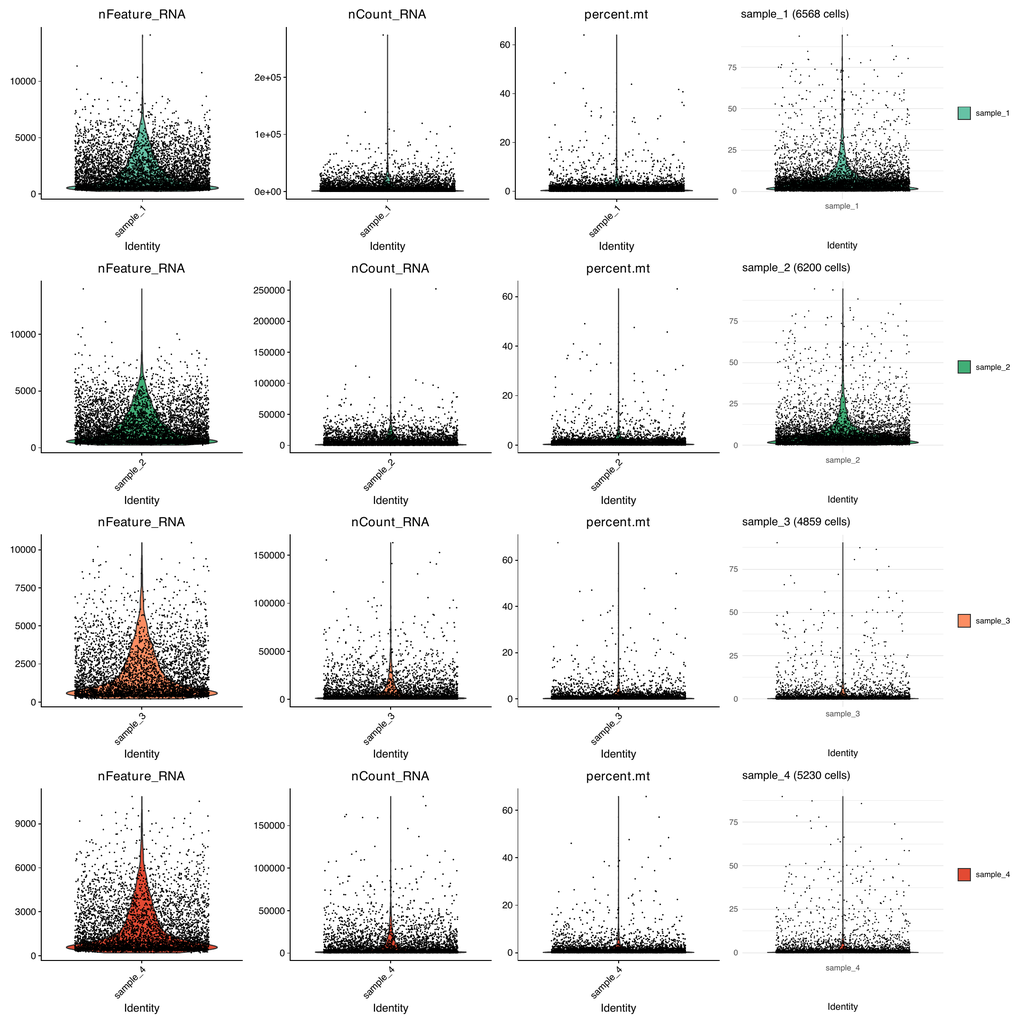

Pre-filter QC violin plots.

## 0.6 Section 2 - CELL FILTERING AND DOUBLET DETECTION

```r
output_dir <- dir_01
seurat_list <- filter_seurat_samples(seurat_list_raw, min_features = 200, max_mt = 5)
plot_qc_batch(seurat_list, colors, "qc_postfilter.pdf")
saveRDS(seurat_list, file.path(dir_objects, "seurat_list_postfilter.rds"))
message("\nOK SECTION 2 COMPLETE: Filtering and doublet detection complete")
```

Representative output from Section 2:

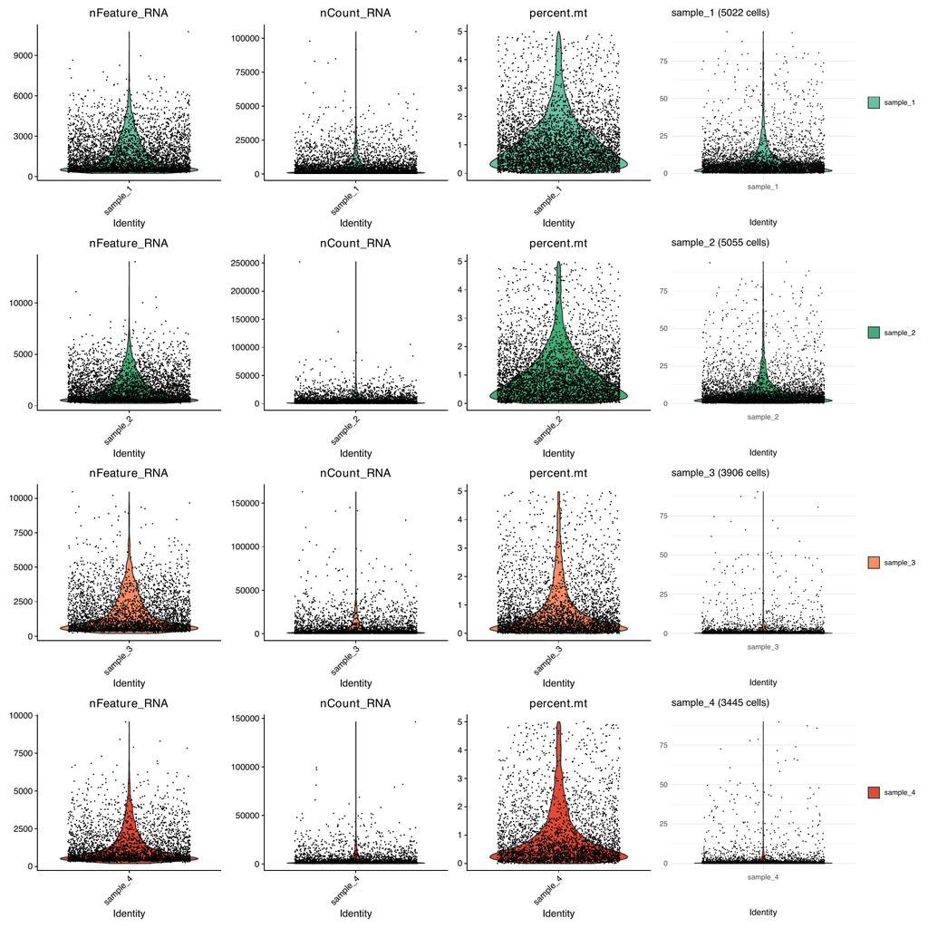

Post-filter QC violin plots.

## 0.7 Section 3 - MERGE AND INITIAL PREPROCESSING

```r
output_dir <- dir_01
pbmc_harmony <- reduce(seurat_list, merge) %>%
  NormalizeData(verbose = FALSE) %>%
  FindVariableFeatures(selection.method = "vst", nfeatures = 2000, verbose = FALSE) %>%
  ScaleData(verbose = FALSE) %>%
  RunPCA(npcs = 30, verbose = FALSE) %>%
  RunUMAP(reduction = "pca", dims = 1:30, verbose = FALSE)
save_pdf(DimPlot(pbmc_harmony, group.by = "orig.ident", cols = colors),
         "umap_preharmony.pdf")
saveRDS(pbmc_harmony, file.path(dir_objects, "pbmc_harmony_preharmony.rds"))
message("\nOK SECTION 3 COMPLETE: Merge and preprocessing complete")
```

Representative output from Section 3:

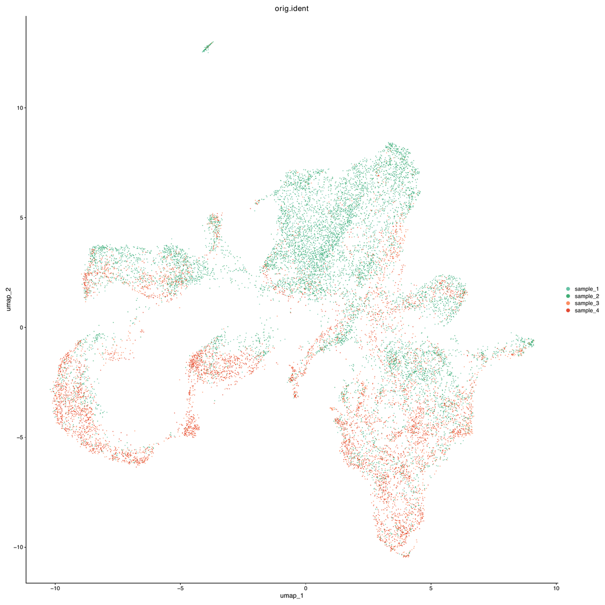

UMAP before Harmony correction, colored by sample.

## 0.8 Section 4 - HARMONY BATCH CORRECTION

```r
output_dir <- dir_01
pbmc_harmony <- pbmc_harmony %>%
  RunHarmony("orig.ident", plot_convergence = FALSE) %>%
  RunUMAP(reduction = "harmony", dims = 1:30, verbose = FALSE)
save_pdf(DimPlot(pbmc_harmony, group.by = "orig.ident", cols = colors),
         "umap_postharmony.pdf")
saveRDS(pbmc_harmony, file.path(dir_objects, "pbmc_harmony_postharmony.rds"))
message("\nOK SECTION 4 COMPLETE: Harmony integration complete")
```

Representative output from Section 4:

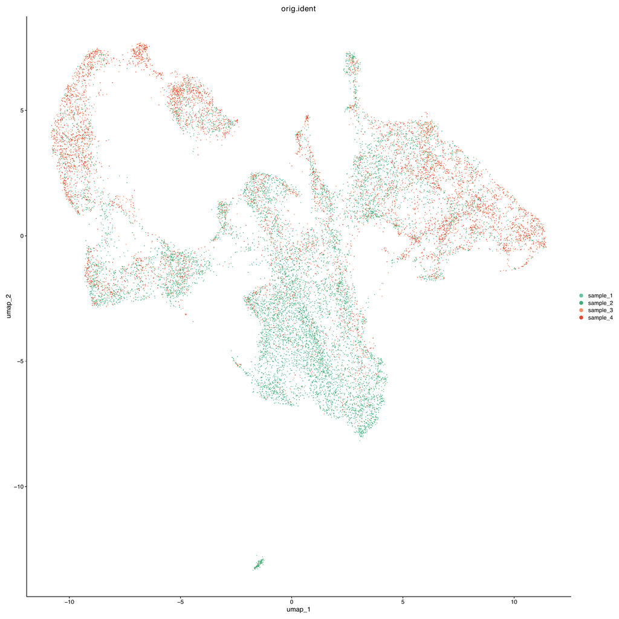

UMAP after Harmony correction, colored by sample.